# Specific Analysis

Laura Plutowski, Franziska Heinkele and Mert Mayadag

25 July 2019

# SPECIFIC ANALYSIS

**Mechanism of vorinostat**

```
## [1] HDAC inhibitor
## 12 Levels: DNA alkyltransferase inhibitor ...
```

**Target of vorinostat**

```
## [1] HDAC1|HDAC10|HDAC11|HDAC2|HDAC3|HDAC5|HDAC6|HDAC8|HDAC9
## 15 Levels: ABL1|ABL2|BLK|EPHA2|FGR|FRK|FYN|HCK|KIT|LCK|LYN|PDGFRB|SRC|SRMS|STAT5B|YES1 ...
```

**Cancer type vorinostat**

```
## [1] cutaneous T-cell lymphoma (CTCL)
## 15 Levels:  ...
```

# Table of content

1. General visualizations

- 1.1. Pie chart of tissue types
- 1.2.Density plot of general gene expression

2. Creation of Vorinostat-FC-matrix

3. Finding biomarkers

- 3.1. Biomarkers received from two-sided T-test
- 3.2. Biomarkers received from FC values
  - 3.2.1. General Biomarkers
  - 3.2.2. Up and Downregulation of biomarkers
- 3.3. Biomarkers received from variance
- 3.4. Comparison of the differently received biomarkers

4. Visualizations of biomarkers

- 4.1. Density plot of biomarker gene expression
- 4.2. Visualization of biomarkers with Vulcanoplot

5.Are the targets for vorinostat (HDACs) part of our biomarkers?

## 1. General visualizations

### 1.1. Pie chart of tissue types

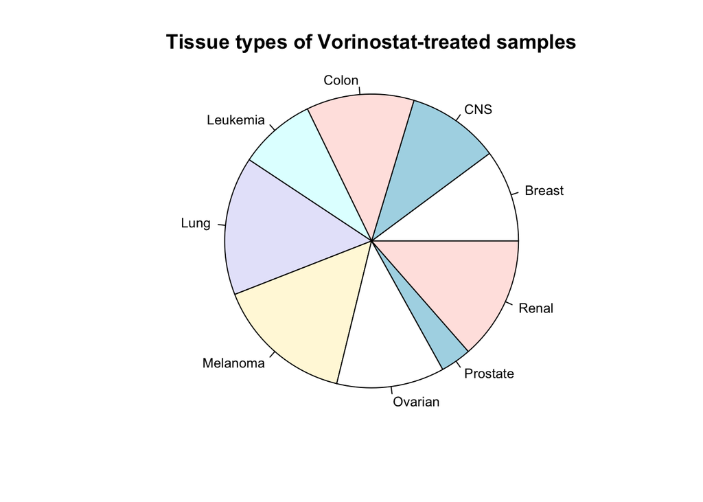

### 1.2.Density plot of general gene expression

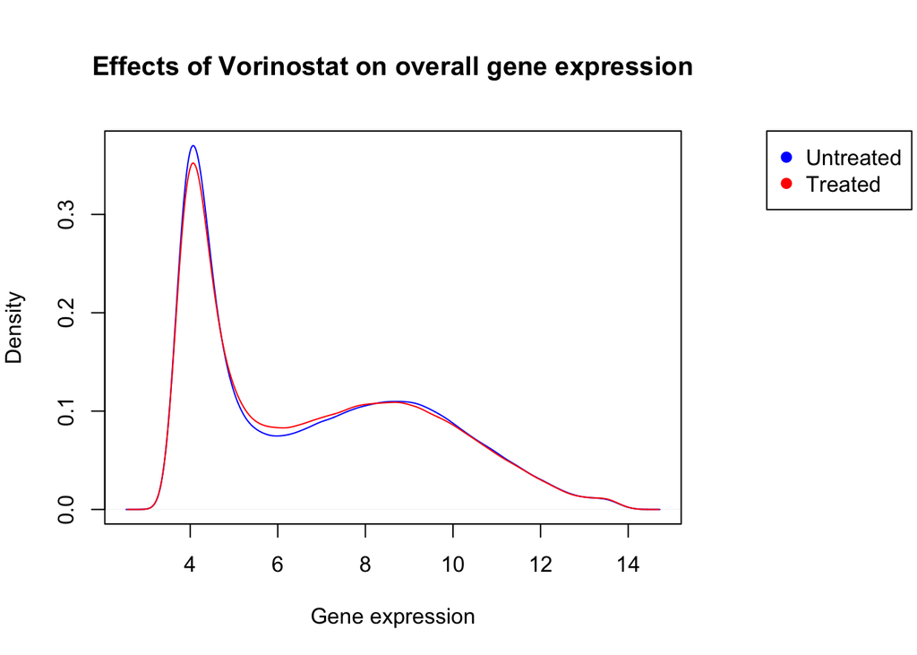

## 2. Create a Vorinostat-FC-matrix

## 3. Finding biomarkers

## 3.1. Biomarkers received from two-sided paired T-test

**Comparison of rows and columns of data frames Treated and Untreated**

```r
identical(rownames(UntreatedVorinostat), rownames(TreatedVorinostat))
```

```
## [1] TRUE
```

```r
head(colnames(UntreatedVorinostat),3)
```

```
## [1] "786-0_vorinostat_0nM_24h" "A498_vorinostat_0nM_24h"
## [3] "A549_vorinostat_0nM_24h"
```

```r
head(colnames(TreatedVorinostat),  3)
```

```
## [1] "786-0_vorinostat_5000nM_24h" "A498_vorinostat_5000nM_24h"
## [3] "A549_vorinostat_5000nM_24h"
```

```r
col_names_VU    = as.data.frame(strsplit(x=colnames(UntreatedVorinostat), split="_"))
col_names_VU    = as.data.frame (t(col_names_VU[1,]))[,1]

col_names_VT    = as.data.frame(strsplit(x=colnames(TreatedVorinostat),split="_"))
col_names_VT    = as.data.frame (t(col_names_VT[1,]))[,1]

identical(colnames(col_names_VU), colnames(col_names_VT))
```

```
## [1] TRUE
```

**Calculation of significance using p-values**

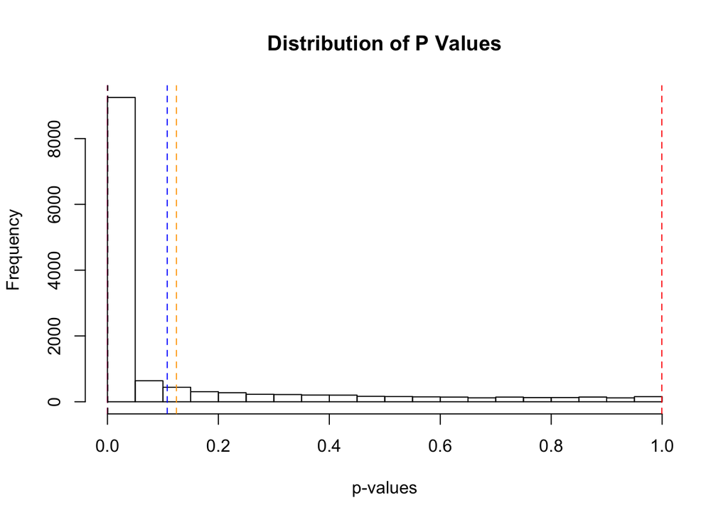

```r
p_values_Vorinostat = sapply(1:13299, function(i){
                      t.test( TreatedVorinostat[i,],UntreatedVorinostat[i,],paired = TRUE,
                                                        alternative = "two.sided")$p.value
})


p_values_Vorinostat           = as.data.frame (p_values_Vorinostat)
rownames(p_values_Vorinostat) = rownames((TreatedVorinostat))
colnames(p_values_Vorinostat) =  " p_values"

hist(p_values_Vorinostat[,1], main="Distribution of P Values", xlab= "p-values")
abline(v = summary(p_values_Vorinostat [,1]), col = c("blue", "red", "black", "orange"),
    lty = 2)
```

```r
Significance_Treated = sapply(1:13299, function(i) {
  # Return whether p-value  is < 0.05
  p_values_Vorinostat [i,] < 0.05
})

p_values_Vorinostat$significance = Significance_Treated

p_values_Vorinostat = p_values_Vorinostat[ order(p_values_Vorinostat$` p_values`), ,drop = FALSE ]


p_values_Vorinostat[1:5,]
```

```
##              p_values significance
## MAP1LC3B 5.230833e-30         TRUE
## TOE1     1.431659e-29         TRUE
## PI4K2A   6.295537e-29         TRUE
## MEPCE    6.616561e-29         TRUE
## ATG101   8.029874e-29         TRUE
```

**Chosing 100 genes showing the smallest p-values**

```r
   biomarkers.pValues = head( p_values_Vorinostat,100 )
head(biomarkers.pValues)
```

```
##              p_values significance
## MAP1LC3B 5.230833e-30         TRUE
## TOE1     1.431659e-29         TRUE
## PI4K2A   6.295537e-29         TRUE
## MEPCE    6.616561e-29         TRUE
## ATG101   8.029874e-29         TRUE
## DPM1     1.965209e-28         TRUE
```

```r
biomarkers.genes= rownames(biomarkers.pValues)
```

### 3.2. Biomarkers received from variance

**Selecting genes showing high variance**

```r
Variances_Untreated             = as.data.frame (apply(UntreatedVorinostat,1,var))

colnames(Variances_Untreated)[1]= "var"
Most_Variances_Unt              = Variances_Untreated[ order(-Variances_Untreated$var), , drop= FALSE ]

nintyfive_quartile_Untr         = quantile(Variances_Untreated$var, probs = 0.95)

Most_Variances_Unt              = Most_Variances_Unt[
                                 -which(Most_Variances_Unt$var < nintyfive_quartile_Untr),, drop= FALSE]
```

**Creating data frames from Treated and Untreated only with the selected genes**

**Selecting genes with diminished variances after treatment**

```r
Variances_Untreated             = as.data.frame (apply(Highly_variant_Untreated,1,var  ))
Variances_Treated               = as.data.frame (apply(Highly_variant_Treated,1,var  ))

Variance_Change                 = as.data.frame (Variances_Treated[,1] - Variances_Untreated[,1])

row.names(Variance_Change)      = rownames(Variances_Treated)
colnames(Variance_Change)[1]    = "Var_Change"

lower_quartile_VC               = quantile (Variance_Change$Var_Change, probs = 0.05)
Most_neg_var_change             = Variance_Change[-which(
                                  Variance_Change$Var_Change > lower_quartile_VC),, drop= FALSE]

Most_neg_var_change             = Most_neg_var_change[
                                  order(Most_neg_var_change$Var_Change), ,drop = FALSE ]
```

**Selecting 30 genes with highest negative variance change**

**Do these genes show similar responses in a specific cancer type?**

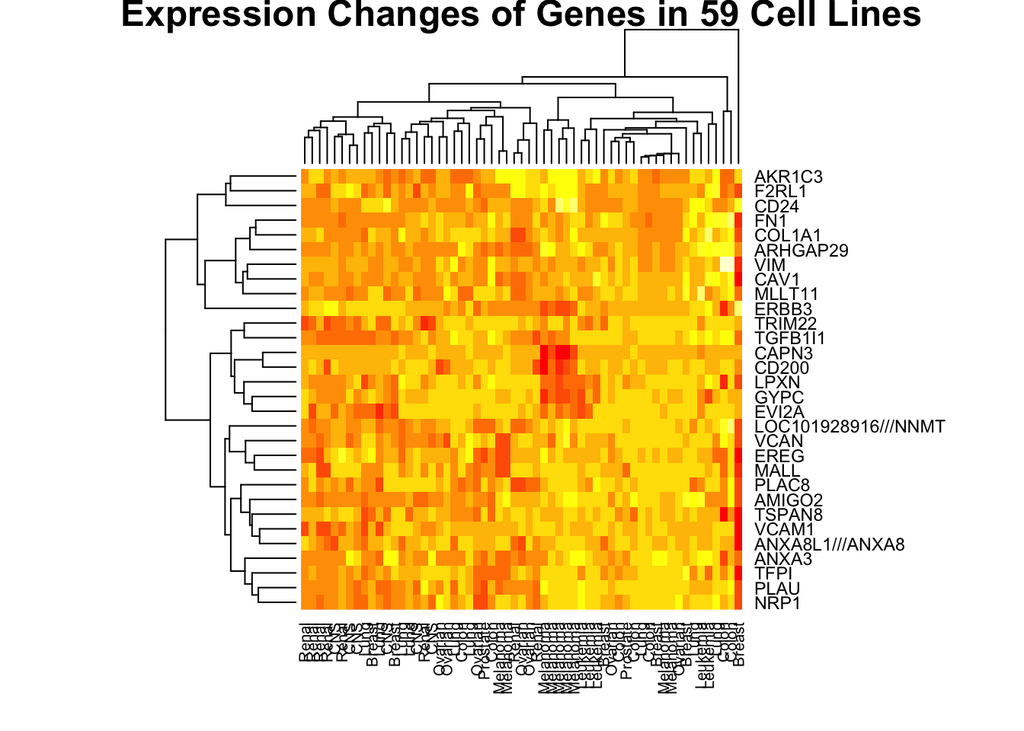

```r
heatmap(Highest_VC_Biomarkers, main = "Expression Changes of Genes in 59 Cell Lines")
```

## 3.3. Biomarkers received from FC values

### 3.3.1.General biomarkers

**Find biomarkers using absolute FC Values**

```r
FC <- TreatedVorinostat - UntreatedVorinostat

FCVorinostatabs= abs(FC)
FCVorinostatmean <- apply(FCVorinostatabs, 1, mean)

#sort the values to get the 100 largest values:
sortedgeneralbiomarker <- sort(FCVorinostatmean, decreasing = TRUE)
sortedgeneralbiomarker <- as.matrix(sortedgeneralbiomarker)

#select the top 100 general biomarkers:
top100generalbiomarkers = sortedgeneralbiomarker[1:100,]
top100generalbiomarkers <- as.matrix(top100generalbiomarkers)

#Create a vector with gene names:
generalbiomarkergenes = row.names(top100generalbiomarkers)
```

Top generalbiomarkers

| DHRS2 | 1.747967 |
| --- | --- |
| ABAT | 1.309399 |
| SERPINI1 | 1.235481 |
| MIR612///NEAT1 | 1.212957 |
| CLU | 1.043344 |
| HBA2///HBA1 | 1.035618 |

### 3.3.2. Up- and Downregulation of biomarkers

**Biomarker without absolute values**

```r
FC_meanrow= rowMeans(FC)

# look at the absolute values:
FC_meanrow = abs(FC_meanrow)

# sort the FC
sortedFC <- sort(FC_meanrow, decreasing = TRUE)
sortedFC <- as.matrix(sortedFC)

# take the first 100 values for comparison
FC100<- sortedFC[1:100,]
FC100 <- as.matrix(FC100)

# create a vector with genenames
biomarkergenes_noabs = row.names(FC100)
```

Top biomarkers without absolute values

| DHRS2 | 1.717772 |
| --- | --- |
| ABAT | 1.294360 |
| SERPINI1 | 1.226295 |
| MIR612///NEAT1 | 1.205070 |
| CLU | 1.026127 |
| HBA2///HBA1 | 1.022808 |

**Do we get the same biomarkers?**

```
## [1] FALSE
```

**How many of the biomarkers are different?**

```
## [1] 5
```

```
## [1] "POLE2"   "TXNDC15" "NGFR"    "UBTF"    "GINS3"
```

**Are the genes up- or down regulated?**

```r
FCVorinostatmean_noabs= rowMeans(FC)

#Matrix with information about general up- or downregulation:
FCVorinostatmean_noabs_matrix <- as.matrix(FCVorinostatmean_noabs)

#loop, which adds those biomarkergenes to a vector, which are mostly upregulated:
i=1
Upregulated <- c()
while(i<=100) {
  if(FCVorinostatmean_noabs_matrix[generalbiomarkergenes[i],1] >0) {
    Upregulated <- union(Upregulated, generalbiomarkergenes[i])
  }
  i=i+1}

#Create a vector that includes for each gene sequentially if it is up- or downregulated:
i=1
Generalchange <- c()
while(i<=100) {
  if(FCVorinostatmean_noabs_matrix[generalbiomarkergenes[i],1] >0) {
    Generalchange <- append(Generalchange, "Up")
  } else {
    Generalchange <- append(Generalchange, "Down")
  }
  i=i+1}

# Bind the information about up/downregulation as a new column to the biomarkermatrix:
top100generalbiomarkers_withUporDown <- cbind(top100generalbiomarkers, Generalchange)
# rename
colnames(top100generalbiomarkers_withUporDown)[1] <- "FCmean"
head(top100generalbiomarkers_withUporDown)
```

```
##                FCmean             Generalchange
## DHRS2          "1.74796747187396" "Up"
## ABAT           "1.30939911773294" "Up"
## SERPINI1       "1.23548131984129" "Up"
## MIR612///NEAT1 "1.21295661353487" "Up"
## CLU            "1.043343937109"   "Up"
## HBA2///HBA1    "1.03561789420936" "Up"
```

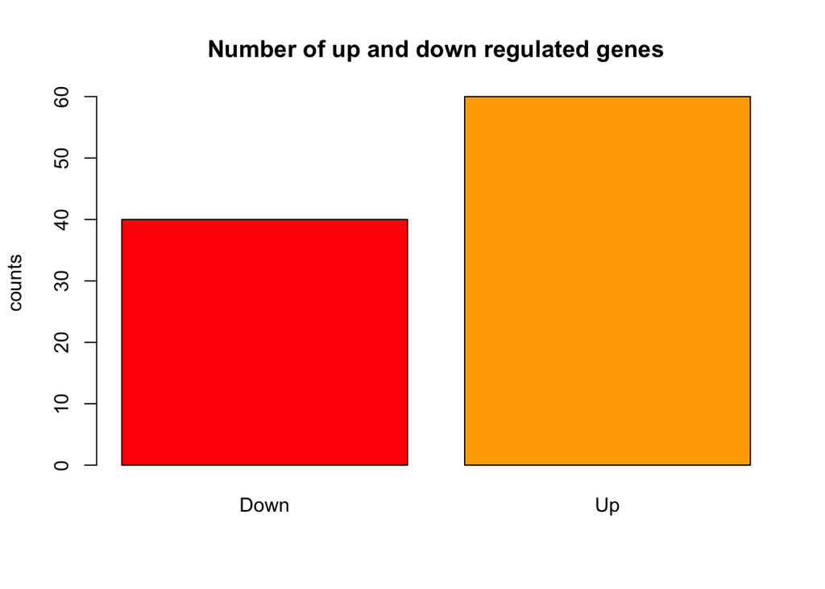

# **TAKE THE BIOMARKERS FROM ABSOLUTE FC VALUES**

## 4. Visualizations of biomarkers

### 4.1. Density plot of biomarker gene expression

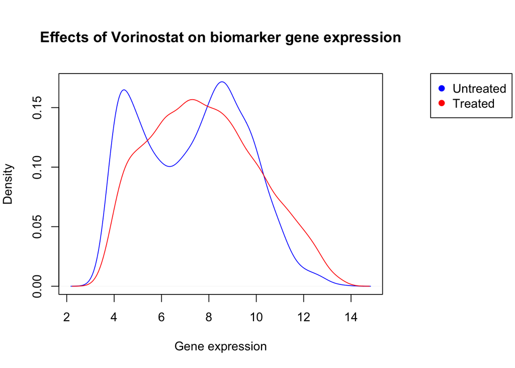

### 4.2. Visualization of biomarkers with Vulcanoplot

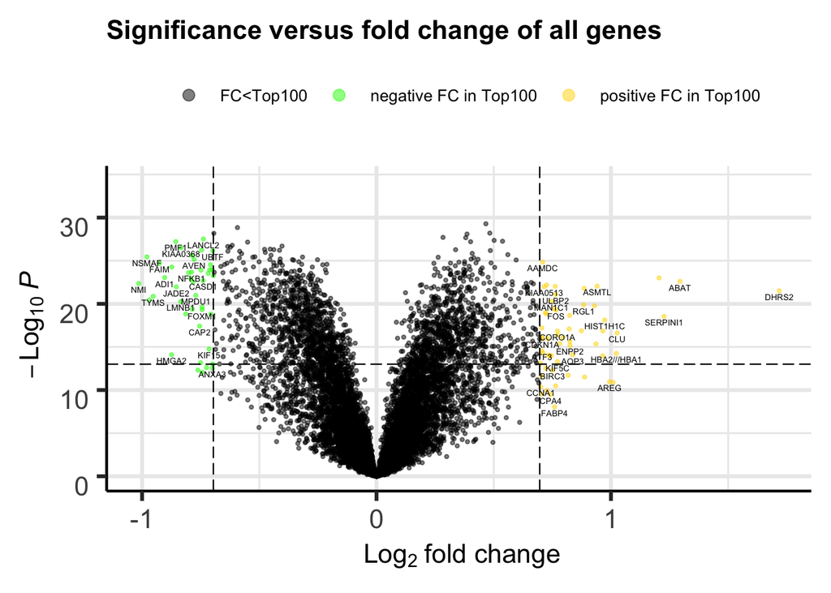

## 5. Are the targets for vorinostat (HDACs) part of our biomarkers?

**What are the targets of vorinostat?**

```
## [1] HDAC1|HDAC10|HDAC11|HDAC2|HDAC3|HDAC5|HDAC6|HDAC8|HDAC9
## 15 Levels: ABL1|ABL2|BLK|EPHA2|FGR|FRK|FYN|HCK|KIT|LCK|LYN|PDGFRB|SRC|SRMS|STAT5B|YES1 ...
```

**Do we have HDACs in our biomarkers?**

```
## [1] 0
```

**Which FC values do they have?**

FC values vorinostat targets

| FC_meanrow | genes |
| --- | --- |
| 0.1248735 | HDAC1 |
| 0.0247844 | HDAC11 |
| 0.0119615 | HDAC2 |
| 0.4081318 | HDAC3 |
| 0.4662200 | HDAC5 |
| 0.1102505 | HDAC6 |

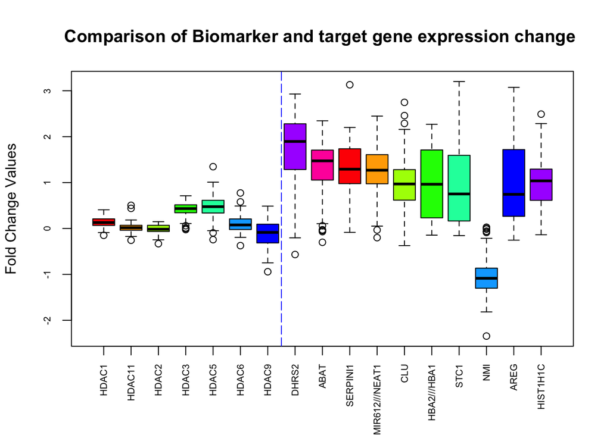

# **NEXT: What are the functions of the biomarkers?**